# Mapas

Teresa Ortiz

#### Instrucciones

1. Lo primero es instalar las librerías maptools y gdal. Las usaremos para cargar datos.
2. Si desean correr el código de este script tal como esta, necesitan guardar los datos de la siguiente manera:
- este script (mapas.Rmd), y los archivos: Municipios.dbf, Municipios.shp, Municipios.shx, etc. deben estar en la misma carpeta,
- después crea una carpeta llamada data (dentro de la carpeta anetrior) y guarda los archivos ESTADOS.dbf, ESTADOS.shp y ESTADOS.shx (si copiaste la carpeta completa que subí al sitio esta estructura ya está).
3. Asegurate de que tu directorio de trabajo sea el mismo que el directorio donde estan guardados los scripts (puedes usar Rstudio ó los comandos getwd() para saber cual es tu directorio y setwd(“path_directorio”) para definir el nuevo directorio de trabajo).
4. **Importante** los archivos shp que yo usé en este script están **muy** pesados, es mejor idea usar los mapas que estan en las carpetas “estados_ligera” y “municipios_ligera”, solo deben sustituirlos y los scripts correrán igual, noten que hay más archivos en los *pesados* (.prj, .sbn, .sbx) pero no son necesario para que corra.

Comenzamos cargando los paquetes que vamos a usar,

#### Shapefile

Un *shapefile* es un grupo de archivos que contienen geometrías e información de acuerdo a un estándar especificado por el Insituto de Investigación en Sistemas de Ecosistemas (ESRI). Nosotros tenemos los siguientes grupos de archivos (para estados): * Estados.shp  
* Estados.dbf  
* Estados.shx  
* Estados.prj  
* Estados.sbn  
* Estados.sbx

El archivo .shp es el archivo principal y contiene la geometría correspondiente, el .db contiene los atributos de la geometría. El archivo .prj contiene información de la proyección, lo veremos más adelante, pero es importante cuando se trabaja con más de un shapefile pues pueden tener distintas proyecciones.

Veamos las librerías que usaremos

```r
library(ggplot2)
library(dplyr)
library(maptools)
library(rgdal)
```

Usamos la función readOGR para leer los archivos de municipios

```r
mun_shp <- readOGR("." , "Municipios")
```

```
## with 2456 features and 6 fields
## Feature type: wkbPolygon with 2 dimensions
```

el “.” indica que los archivos están en el directorio en el que estamos trabajando.

Notemos que el objeto mex_mun no es un data frame,

```r
class(mun_shp)
```

```
## [1] "SpatialPolygonsDataFrame"
## attr(,"package")
## [1] "sp"
```

Lo podemos graficar directamente con plot

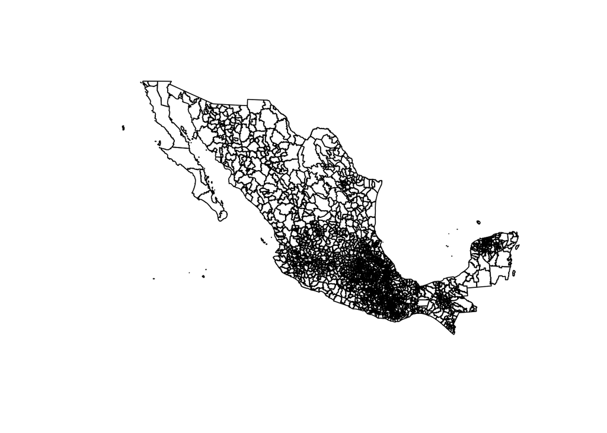

```r
plot(mun_shp)
```

pero para poder graficarlo con ggplot debemos convertirlo en data frame.

Los atributos que relacionan las bases de datos deben ser explícitos (shp y dbf), es por ello asignamos el id a mun_shp, la información que asignamos viene del archivo dbf.

```r
mun_shp@data$id = rownames(mun_shp@data)
```

Y ahora formamos el data frame (con fortify) que convierte los polígonos en puntos, les asigna el id correspondiente, y asigna también un *grupo* que indica a que polígono corresponde cada punto.

```r
mun_df <- fortify(mun_shp, region = "id")
```

[output not shown]

```r
class(mun_df)
```

```
## [1] "data.frame"
```

```r
head(mun_df)
```

```
##      long    lat order  hole piece group id
## 1 2793795 814558     1 FALSE     1   0.1  0
## 2 2793840 814544     2 FALSE     1   0.1  0
## 3 2793875 814536     3 FALSE     1   0.1  0
## 4 2793930 814527     4 FALSE     1   0.1  0
## 5 2793970 814522     5 FALSE     1   0.1  0
## 6 2793993 814521     6 FALSE     1   0.1  0
```

Ya estamos listos para graficar, usaremos la geometría polígono (este tarda mucho, mejor saltarse).

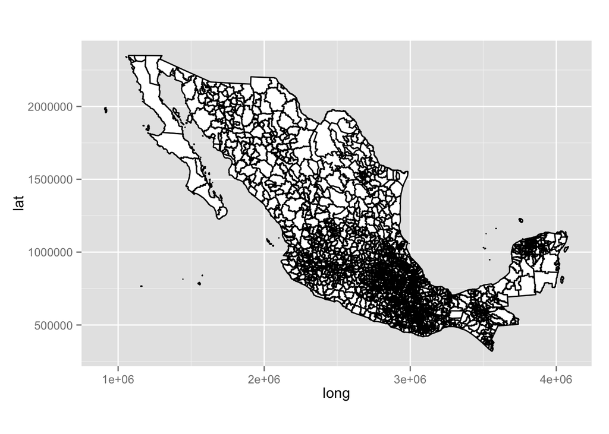

```r
ggplot(data = mun_df, aes(long, lat, group=group)) +
  geom_polygon(colour='black', fill='white') + coord_fixed()
```

Ahora supongamos que solamente deseamos graficar los municipios de Guanajuato. Lo más sencillo es filtrar antes de hacer la instrucción fortify; sin embargo, el objeto que se crea al leer los *shapefiles* no es un *data frame* por lo que debemos usar subset.

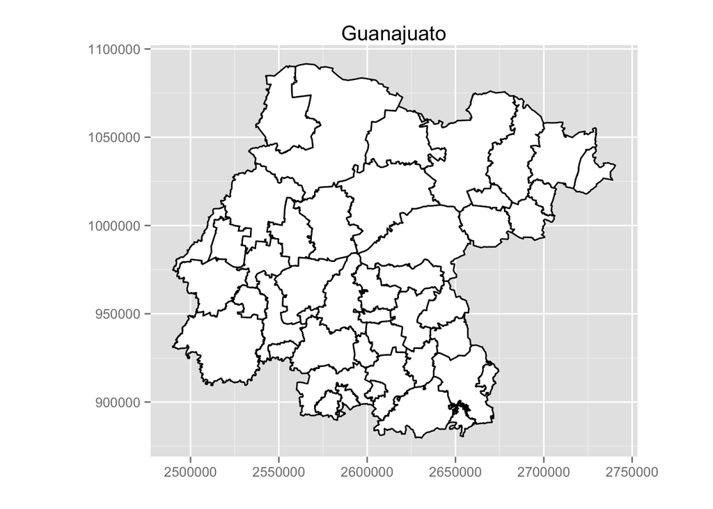

```r
gto_shp <- subset(mun_shp, CVE_ENT == 11)
gto_df <- gto_shp %>%
  fortify(region = "id") %>%
  arrange(order)

ggplot(gto_df, aes(long, lat, group=group)) +
  geom_polygon(colour='black', fill='white') + coord_fixed() +
  labs(title = "Guanajuato", x = "", y = "")
```

La instrucción para leer *shapefiles* en el paquete *rgdal* es readORG, en el caso de municipios sería:

```r
mun_shp <- readOGR(".", layer = "Municipios")
```

```
## with 2456 features and 6 fields
## Feature type: wkbPolygon with 2 dimensions
```

Para leer los estados sería:

```r
edo_shp <- readOGR("estados_ligero", layer = "Mex_Edos")
```

```
## with 32 features and 1 fields
## Feature type: wkbPolygon with 2 dimensions
```

estados_ligero es la carpeta con los archivos y Mex_Edos el nobre de los shapefiles.

Además tenemos algunas instrucciones que nos dan más información de los archivos

```r
ogrFIDs("estados_ligero", layer = "Mex_Edos")
```

```
##  [1]  0  1  2  3  4  5  6  7  8  9 10 11 12 13 14 15 16 17 18 19 20 21 22
## [24] 23 24 25 26 27 28 29 30 31
## attr(,"nf")
## [1] 32
## attr(,"i")
## [1] 32
```

nos dice cuáles son los identificadores de los polígonos.

También puede ser importante conocer la proyección del mapa, en nuestro caso es [North America Lambert Conformal Conic Projection](http://en.wikipedia.org/wiki/Lambert_conformal_conic_projection), la información de la proyección está almacenada en el archivo Municipios.prj. Para saber qué proyección estamos usando podemos hacer la siguiente instrucción:

```r
ogrInfo(dsn = "data", layer = "Estados")
```

```
## Driver: ESRI Shapefile number of rows 32
## Feature type: wkbPolygon with 2 dimensions
## Extent: (907822 319149) - (4082997 2349615)
## CRS: +proj=lcc +lat_1=17.5 +lat_2=29.5 +lat_0=12 +lon_0=-102 +x_0=2500000 +y_0=0 +ellps=GRS80 +units=m +no_defs
## LDID: 87
## Number of fields: 5
##         name type length typeName
## 1   OBJECTID    0      9  Integer
## 2    CVE_ENT    4      2   String
## 3    NOM_ENT    4     70   String
## 4 Shape_Leng    2     19     Real
## 5 Shape_Area    2     19     Real
```

y el atributo CRS (Coordinate Reference System) indica **lcc**, que corresponde a Lambert Conformal Conic, también nos dice que las unidades son metros y [más](https://www.nceas.ucsb.edu/~frazier/RSpatialGuides/OverviewCoordinateReferenceSystems.pdf).

El mapa quedaría,

```r
edo_shp@data$id <- rownames(edo_shp@data)
edo_df <- edo_shp %>%
  fortify(region = "id") %>%
  mutate(id = as.numeric(id)) # hacemos el id numérica

head(edo_df)
```

```
##     long   lat order  hole piece group id
## 1 -102.1 22.30     1 FALSE     1   0.1  0
## 2 -102.1 22.30     2 FALSE     1   0.1  0
## 3 -102.1 22.29     3 FALSE     1   0.1  0
## 4 -102.1 22.29     4 FALSE     1   0.1  0
## 5 -102.1 22.29     5 FALSE     1   0.1  0
## 6 -102.1 22.29     6 FALSE     1   0.1  0
```

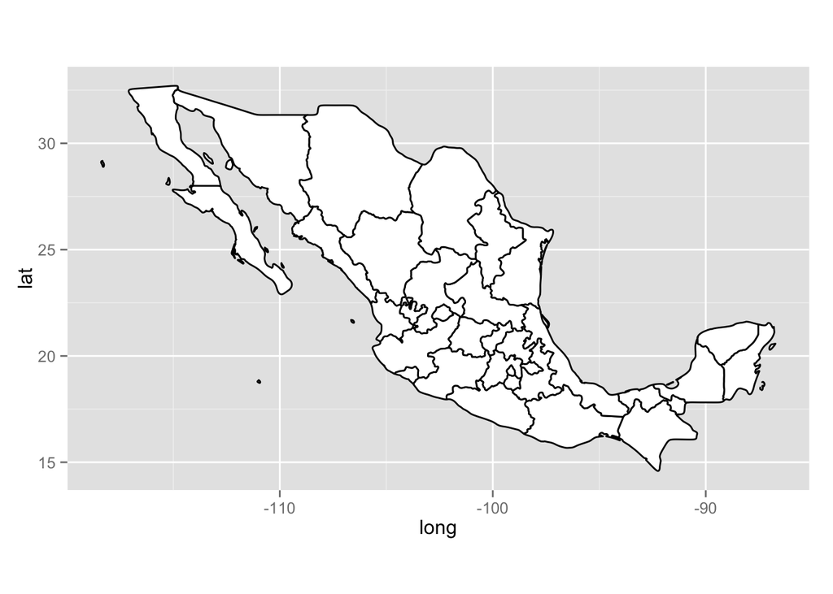

```r
ggplot(data = edo_df, aes(long, lat, group = group)) +
  geom_polygon(colour='black', fill='white') + coord_fixed()
```